# SoupLadle

## Linear sum assignment

For the optimal assignment of each demultiplexed single-cell cluster to individual SNPs from bulk, we binarize the genotype information so that we can calcaute the distance between patients based on their SNP profile:

```r
SOUP_bin <- Binarize_genotype_values(SOUP)
BULK_bin <- Binarize_genotype_values(BULK)
```

Than estimate the distance matrix and solve the linear sum assignment:

```r
dist_matrix <- SNP_based_assignment(t(SOUP_bin), t(BULK_bin))
```

Lets have a look at the assignments:

```r
dist_matrix$Assignments
```

```
#>   Reference Cluster
#> 1     KH_75       0
#> 2     KH_77       1
#> 3     KH_76       2
#> 4     KH_79       3
#> 5     KH_78       4
```

Having assigned the demultiplexed sc clusters to patients, we can add this to the meta data and output of the demutliplexing. If the output_csv is true, we wil generate a csv file of the meta data that can be used later or outside R.

```r
cluster_file <- system.file("extdata", "clusters.tsv", package = "SoupLadle")
demultiplexing_file <- read.table(cluster_file, sep="\t", header=TRUE, row.names=1)
meta_data <- Assignment_meta_data(assignment_df = dist_matrix$Assignments, clusters = demultiplexing_file, output_csv = TRUE, output_file = "SoupLadle_Assignments.csv")
```

Here, we will continue with Seurat and first load the pre-processed Seurat object of the PBMC scRNA-seq data set that has been labeled by CMO before demultiplexing so that we can compare both approaches. For the comparision, we rename the clusters and add them to the Seurat object:

```r
load(file=(system.file("extdata", "PBMC_subsampled.rda", package = "SoupLadle")))
PBMC
```

```
#> An object of class Seurat
#> 36601 features across 2500 samples within 1 assay
#> Active assay: RNA (36601 features, 4000 variable features)
#>  2 layers present: counts, data
#>  1 dimensional reduction calculated: umap
```

```r
Patient_colors <- c("#195E83", "#DFC8A2", "#E07B39", "#69BDD2", "#80391E", "#606060", "gray")

clusters <- meta_data %>%
  mutate(SoupLadle  = recode(SoupLadle,
                             "KH_75" = "Patient_1",
                             "KH_77" = "Patient_2",
                             "KH_79" = "Patient_3",
                             "KH_76" = "Patient_4",
                             "KH_78" = "Patient_5"),
  )

PBMC <- AddMetaData(PBMC, metadata = clusters)
```

Note that the data is not unfiltered, so that we can evaluate the quality and identify doublets (and might filter them out before downstream analysis):

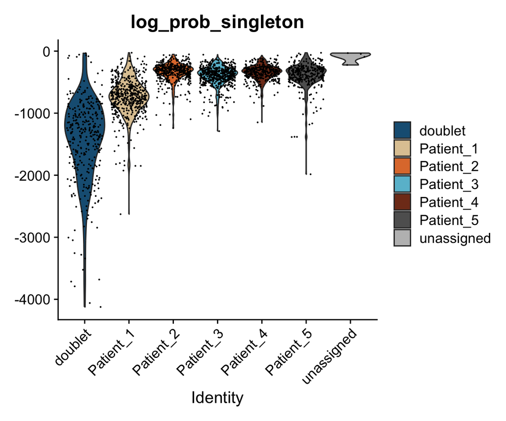

```r
#Violin QC plots
VlnPlot(PBMC, features = c("log_prob_singleton"), group.by = "SoupLadle")+scale_fill_manual(values = Patient_colors)
```

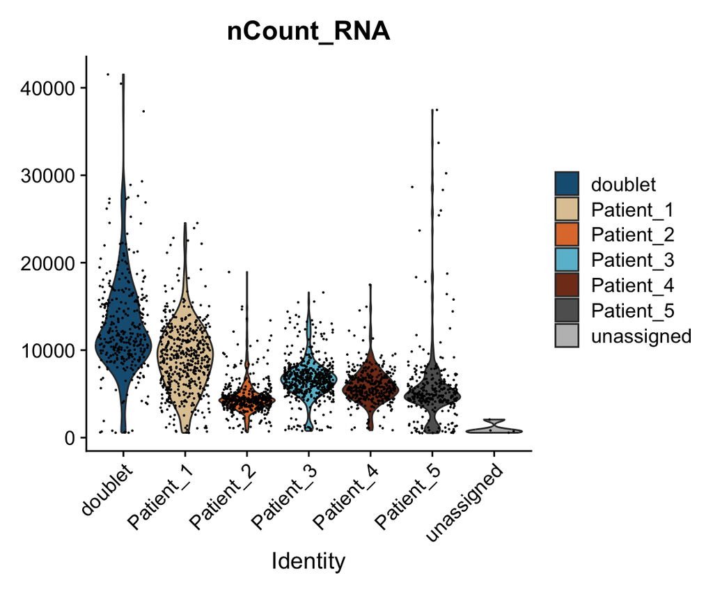

```r
VlnPlot(PBMC, features = c("nCount_RNA"), group.by = "SoupLadle")+scale_fill_manual(values = Patient_colors)
```

The total number of molecules (nCount_RNA) is low in the unassigned cells, which might result in a low amount of discriminative SNPs. Doublets are characterized by a high count of molecules as expected. The higher nCount_RNA value for Patient_1 might be explained by the data set, which has been FACS sorted for specific cell types to evaluate the scRNA-seq demultiplexing. We can visualize it as UMAP as well:

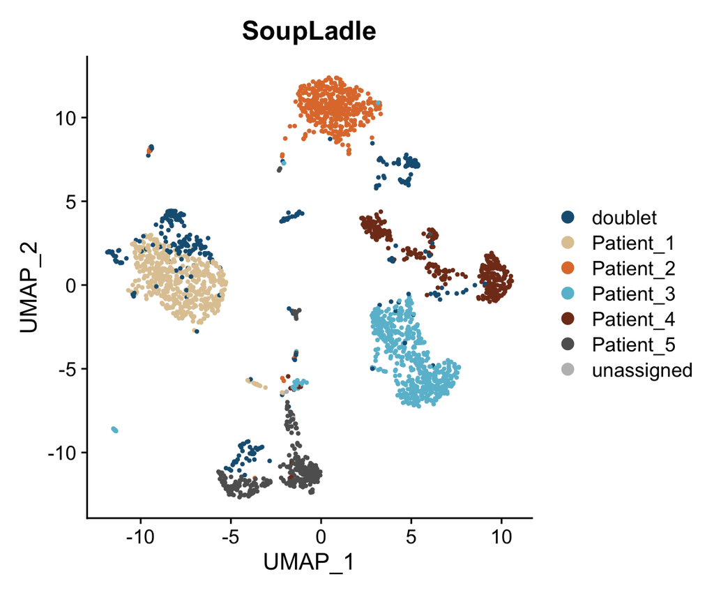

```r
DimPlot(PBMC, group.by = c("SoupLadle"))+scale_color_manual(values = Patient_colors)
```

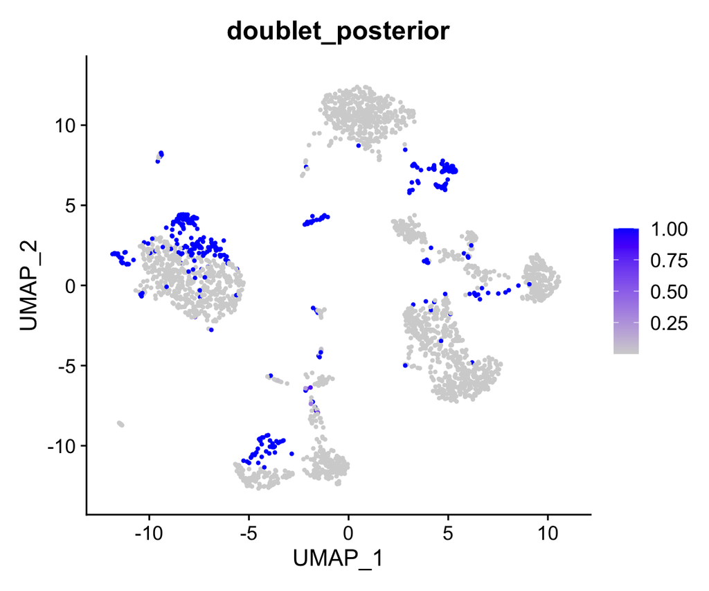

```r
FeaturePlot(PBMC, features = c("doublet_posterior"))
```

Since the sc samples have been labeled in this case before pooling, we can compare the labeling and SNP-based demultiplexing by first plotting the UMAP:

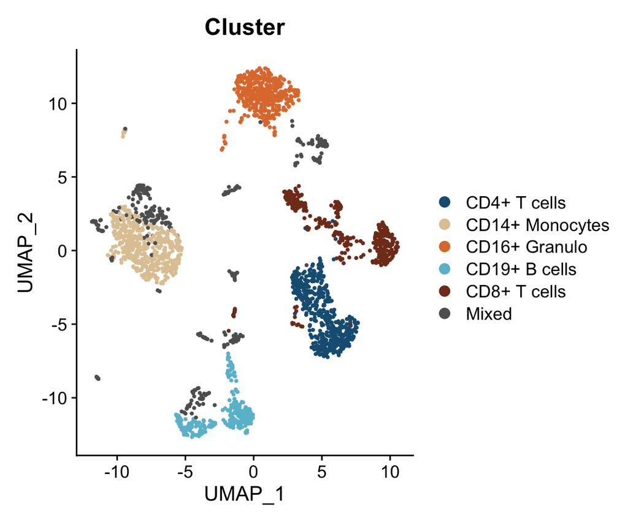

```r
DimPlot(PBMC, group.by = c("Cluster"))+scale_color_manual(values = Patient_colors)
```

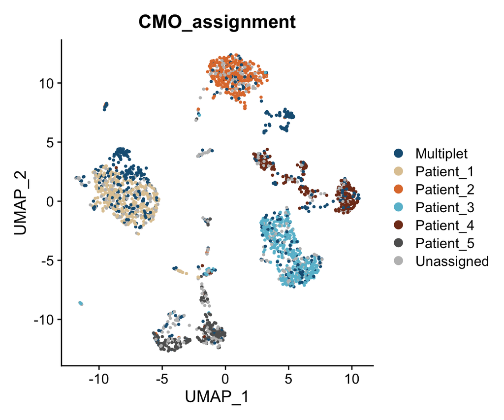

```r
DimPlot(PBMC, group.by = c("CMO_assignment"))+scale_color_manual(values = Patient_colors)
```